# SuMMITS downscaled data presentation

damien g. (damien.georges2 at gmail.com)

## What is this document for?

This document aims to present the downsclaled version of past temperature for mountains of the **SUMMITS** project. For each location **30s resolution** version of past monthly/seasonal mean temperature have been produced based on **cru_ts 4.02**, **casty 2007**, **Xoplaki 2005** downscaled according to the latest version of **worldclim** data.

## where are the downscaled data?

Data are currently stored on the Ecoinformatics network drive at the locataion :

I:/C_Write/Damien/SUMMITS/OUTPUTS/summits_downsc_temp.csv

## What data has been used?

The aim of this procedure is to produce 30s resolution monthly/seasonal mean temperature from 1800 to nowadays.

### Higher resolution data

To downscale the past climatic data from 0.5deg resolution to 30s resolution we used the **worldclim monthly mean temperature**.  
*download link*: http://www.worldclim.org/current  
*ref*: Hijmans, R.J., S.E. Cameron, J.L. Parra, P.G. Jones and A. Jarvis, 2005. Very high resolution interpolated climate surfaces for global land areas. International Journal of Climatology 25: 1965-1978.  
*extra info*: http://www.worldclim.org/methods

**note**: we also used the **worldclim elevation** data to correct predicted predicted temperature according to the differences between worlclim elevation and summits observed elevatrion (we use a **-0.6deg / 100m** correction factor)

## Downscale procedure

Here is a schematic representation of the downscale procedure:

[figure not shown]

downscaling procedure scheme

The main downscaling procedure should be summarised in 3 main steps:

1. Calculating the **Δ temp due to climatic source**: anomalies between worldclim and one of the past cliamtic dataset (PCD)
   - we extract the mean monthly temperature from WorldClim layer for one summit location
   - we extract the mean temperature from PCD for the matching period (same month(s) from 1950 to 2000) and compute the average value
   - we deduce the anomaly associated to the PCD for this summit
2. Calculating the **Δ temp due to elevation correction**: correction of temperature according to altitudinal difference between woldclim elevation layer and the observed elevation of our summit
3. Calculate the **downscaled past temperature** of our summit: we simply add the two Δ to the raw past temperature extraction

## Source code

If you want to see exactly how the downscale procedure have been proceed, you should refer to the source code available here :  
https://github.com/DamienGeorges/summitshub/tree/master/scripts  
Scripts workflow is the following (some scripts needs outputs of others to be run):  
1. cell_extraction_and_polygons.R  
2. climatic_sources_comparison.R  
3. climatic_sources_mean_tmp_extraction.R  
4. downscale_mean_temperature.R

Optionaly: - climatic_sources_comparison_graphs.R  
- check_downscaled_mean_temperature.R (to produce this document)

## Donwscaled data exploration

```r
# setwd("/mnt/data/georgesd/_PROJECTS/SUMMITS/WORKDIR/")
rm(list = ls())
```

### load libraries

```r
library(dplyr)
library(tidyr)
library(ggplot2)
```

### basics checkings

Downscaled data are stored within summits_downsc_temp.csv file.

```r
# tmp.dwsc <- read.csv("../OUTPUTS/summits_downsc_temp.csv")
tmp.dwsc <- read.csv("/mnt/data/georgesd/_PROJECTS/SUMMITS/OUTPUTS/summits_downsc_temp.csv")
head(tmp.dwsc)
```

```
##   mountain_id mountain_name   ycoord   xcoord mtn_altitude clim_source
## 1        sds1         Agjek 69.36749 20.42337         1262         cas
## 2        sds1         Agjek 69.36749 20.42337         1262         cas
## 3        sds1         Agjek 69.36749 20.42337         1262         cas
## 4        sds1         Agjek 69.36749 20.42337         1262         cas
## 5        sds1         Agjek 69.36749 20.42337         1262         cas
## 6        sds1         Agjek 69.36749 20.42337         1262         cas
##   year period mean_tmp_dwsc
## 1 1766      1    -12.040774
## 2 1766      2    -11.221097
## 3 1766      3     -7.650129
## 4 1766      4     -3.889484
## 5 1766      5     -1.129484
## 6 1766      6      5.435677
```

In this file we have:

| var name | var type | var description |
| --- | --- | --- |
| **mountain_id** | *character* | a unique id identifying the summit (unique combinasion of summit name, coordinates and altitude) |
| **mountain_name** | *character* | summit name as given in the formal dataset |
| **ycoord** | *numeric* | the raw latitude of the summit (wgs84) |
| **xcoord** | *numeric* | the raw longitude of the summit (wgs84) |
| **mtn_altitude** | *numeric* | the raw elevation of the summit |
| **clim_source** | *character* | the data climatic value values are based on (i.e. cru, cas or xop) |
| **year** | *numeric* | the year oconsidered |
| **period** | *numeric* | the period considered (i.e. 1-12: month (Jan-Dec), 13: winter, 14: spring, 15: summer, 16 fall) |
| **mean_tmp_dwsc** | *numeric* | the 30s resolution downscaled temperature |

### Time scale according to climatic data source

```r
tmp.dwsc %>% group_by(clim_source) %>% summarise(first_year = min(year), last_year = max(year), n_year = length(unique(year)))
```

```
## # A tibble: 3 x 4
##   clim_source first_year last_year n_year
##   <fct>            <dbl>     <dbl>  <int>
## 1 cas               1766      2000    235
## 2 cru               1901      2017    117
## 3 xop               1740      2002    263
```

```r
tmp.dwsc %>% group_by(clim_source) %>% summarise(first_period = min(period), last_period = max(period), n_period = length(unique(period)))
```

```
## # A tibble: 3 x 4
##   clim_source first_period last_period n_period
##   <fct>              <dbl>       <dbl>    <int>
## 1 cas                    1          16       16
## 2 cru                    1          16       16
## 3 xop                   13          16        4
```

### Number of summit considered according to climatic data source

```r
tmp.dwsc %>% group_by(clim_source) %>% summarise(n_mnt = length(unique(mountain_id)))
```

```
## # A tibble: 3 x 2
##   clim_source n_mnt
##   <fct>       <int>
## 1 cas           391
## 2 cru           391
## 3 xop           391
```

```r
tmp.dwsc %>% group_by(clim_source) %>% summarise(n_NA = sum(is.na(mean_tmp_dwsc)), pc_NA = sum(is.na(mean_tmp_dwsc)) / length(mean_tmp_dwsc))
```

```
## # A tibble: 3 x 3
##   clim_source  n_NA   pc_NA
##   <fct>       <int>   <dbl>
## 1 cas          3759 0.00256
## 2 cru          1872 0.00256
## 3 xop         11572 0.0281
```

**note:** some high latitude doesn’t have data for Xoplakis (reduced extent)

```r
na_sites <- function(dd){
  NA_sites = unique(dd$mountain_name[is.na(dd$mean_tmp_dwsc)])
  if(!length(NA_sites)) NA_sites <- NA
  data.frame(clim_source = unique(dd$clim_source), NA_sites = NA_sites)
}
tmp.dwsc %>% group_by(clim_source) %>% do(na_sites(dd = .))
```

```
## # A tibble: 13 x 2
## # Groups:   clim_source [3]
##    clim_source NA_sites
##    <fct>       <fct>
##  1 cas         Svartviktind
##  2 cru         Svartviktind
##  3 xop         Konussen
##  4 xop         Lille_Porsangen
##  5 xop         Lundbohmfjell
##  6 xop         Navaren
##  7 xop         Botn/Brun
##  8 xop         Campbellryggen
##  9 xop         Svartviktind
## 10 xop         Tyven
## 11 xop         Vesuv
## 12 xop         Gattytoppen
## 13 xop         Hjorthfjell
```

### some graphical reperesentations

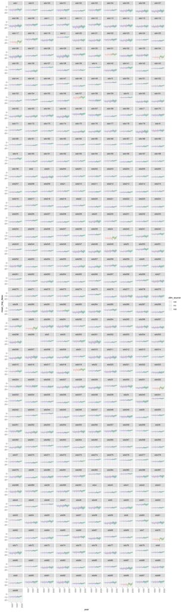

```r
tmp.dwsc.win <- tmp.dwsc %>% filter(period == 13) %>% arrange(mountain_id)
tmp.dwsc.win$mountain_id <- factor(tmp.dwsc.win$mountain_id, levels = gtools::mixedsort(unique(tmp.dwsc.win$mountain_id)))
gg <- ggplot(data = tmp.dwsc.win, mapping = aes(x = year, y = mean_tmp_dwsc, colour = clim_source)) +
  geom_line(alpha = .3) + facet_wrap(~mountain_id, ncol = 10) +
  theme(axis.text.x = element_text(angle=90))
gg
```

#### correspondance between summits id and summits names

```r
mont_ids <- tmp.dwsc %>% select(mountain_id, mountain_name, ycoord, xcoord, mtn_altitude) %>%
   as.data.frame %>% distinct %>% arrange(mountain_name)
```

```r
knitr::kable(mont_ids)
```

| mountain_id | mountain_name | ycoord | xcoord | mtn_altitude |
| --- | --- | --- | --- | --- |
| sds1 | Agjek | 69.36749 | 20.4233725 | 1262.0 |
| sds2 | Alplihorn_Monstein | 46.71083 | 9.8258220 | 3006.0 |
| sds3 | Altenorenstock | 46.86039 | 8.9412590 | 2480.0 |
| sds4 | Aroser_Alplihorn | 46.74832 | 9.6108960 | 2842.0 |
| sds5 | Aroser_Rothorn | 46.73788 | 9.6139570 | 2980.0 |
| sds6 | Arre_Sourins | 42.92528 | 0.3336080 | 2614.0 |
| sds7 | Augstenhuereli | 46.69166 | 9.9032200 | 3027.0 |
| sds8 | Baslersch_Chopf | 46.78146 | 9.9044270 | 2629.0 |
| sds9 | Basòdino | 46.41156 | 8.4684270 | 3272.0 |
| sds10 | Becca_di_Nona | 45.68714 | 7.3660540 | 3142.0 |
| sds11 | Beggistock_Vorgipfel | 46.84916 | 8.9363870 | 2587.0 |
| sds12 | Beinn Hearsgarnich | 56.51020 | -4.5791400 | 1078.0 |
| sds13 | Belianska_kopa | 49.22722 | 20.2238880 | 1835.0 |
| sds14 | Ben Lawers | 56.54556 | -4.2208330 | 1214.0 |
| sds15 | Ben Lui | 56.39704 | -4.8111000 | 1130.0 |
| sds16 | Ben More | 56.38638 | -4.5392670 | 1174.0 |
| sds17 | Bentsjordtinden | 69.51551 | 18.6447032 | 1096.0 |
| sds18 | Berdalseken | 61.20294 | 7.9164609 | 1814.0 |
| sds19 | Bergheien | 69.04640 | 17.4059271 | 563.0 |
| sds20 | Bessho | 61.50523 | 8.7050233 | 2258.0 |
| sds21 | Borterhorn | 46.74372 | 9.8855900 | 2697.0 |
| sds22 | Bos_Fulen | 46.96694 | 8.9455610 | 2802.0 |
| sds23 | BÕtfjellet | 66.85974 | 15.6041295 | 1287.0 |
| sds24 | Botn/Brun | 78.27000 | 16.5200000 | 922.0 |
| sds25 | Broran | 68.89342 | 18.9556001 | 1427.0 |
| sds26 | Bueelenhorn | 46.67244 | 9.7664260 | 2808.0 |
| sds340 | BUHAIESCU | 47.58263 | 24.6324501 | 2221.0 |
| sds27 | Bukkehammaren | 61.47022 | 8.7072311 | 1910.0 |
| sds28 | Camoghe | 46.13486 | 9.0642130 | 2228.0 |
| sds341 | Camp Cairn | 57.09029 | -3.8428500 | 904.0 |

[output cut: 361 more lines]

**note:** As you can see some sites have been replicated because of name encoding..